# RegLinSimple

E.Ing NEKUI TIEFANG BIEDIANT

2023-08-25

```r
library(knitr)
library(rmarkdown)
library(markdown)
```

```r
X = c(20,24,28,22,32,28,32,36,41,41)
Y = c(16,18,23,24,28,29,26,31,32,34)
df=data.frame(X,Y)
df
```

[output not shown]

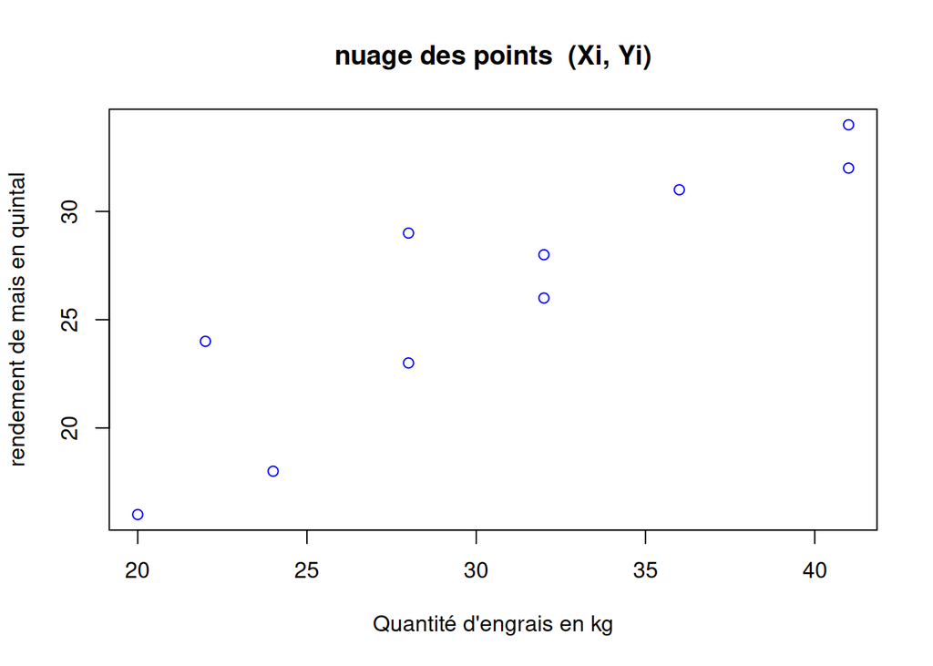

```r
plot(X,Y, col="blue", xlab = "Quantité d'engrais en kg", ylab = "rendement de mais en quintal", main = " nuage des points  (Xi, Yi) ")
```

```r
model =lm(Y~X)
coef(model)
```

```
## (Intercept)           X
##   4.3927701   0.7140536
```

```r
summary(model)
```

```
##
## Call:
## lm(formula = Y ~ X)
##
## Residuals:
##     Min      1Q  Median      3Q     Max
## -3.5301 -1.5983 -0.4557  0.8654  4.6137
##
## Coefficients:
##             Estimate Std. Error t value Pr(>|t|)
## (Intercept)   4.3928     3.9718   1.106 0.300874
## X             0.7141     0.1273   5.609 0.000505 ***
## ---
## Signif. codes:  0 '***' 0.001 '**' 0.01 '*' 0.05 '.' 0.1 ' ' 1
##
## Residual standard error: 2.825 on 8 degrees of freedom
## Multiple R-squared:  0.7973, Adjusted R-squared:  0.7719
## F-statistic: 31.46 on 1 and 8 DF,  p-value: 0.0005049
```

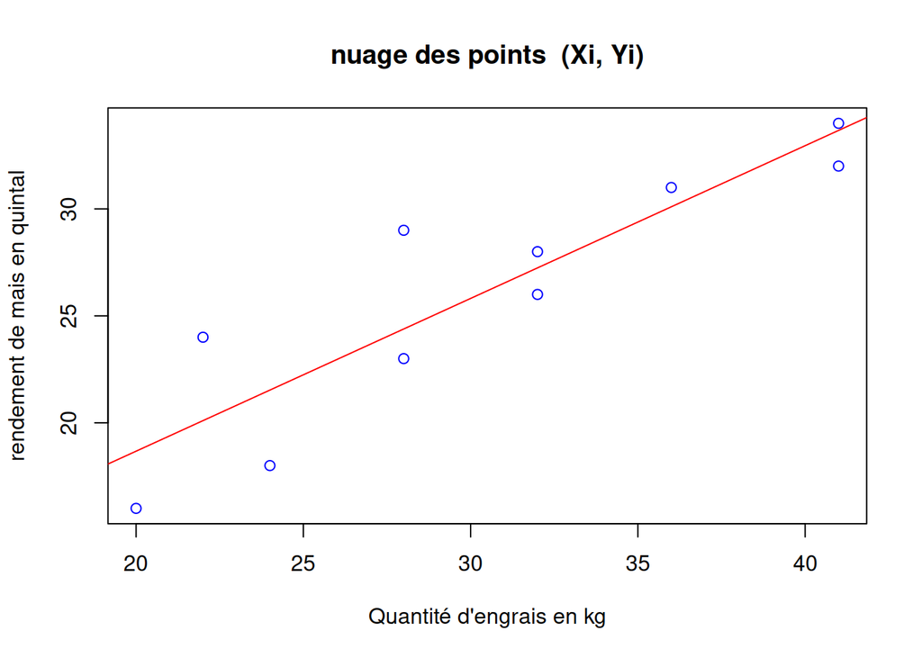

```r
plot(X,Y, col="blue", xlab = "Quantité d'engrais en kg", ylab = "rendement de mais en quintal", main = " nuage des points  (Xi, Yi) ")
abline(model, col = "red")
```

l’equation de la droite ajustée est:
$$Ŷ_{i}=4.3927701 +0.7140536 *X_{i}$$

```r
Ŷ=fitted(model)
resid=residuals.lm(model)
df2=data.frame(X,Y,Ŷ,resid)
df2
```

[output not shown]

5. validité du model ce model est valide si les conditions suivantes sont respectées: 1-linéarité 2-indépendance des residus (test de Durbin-watson pour la correlation des residus) 3-Homoscedasticité 4-normalité des residus (shapiro-wilk) 5-absence de valeurs aberrantes (toute les valeurs doivent êtres représentes)

   5-1) *linearité*

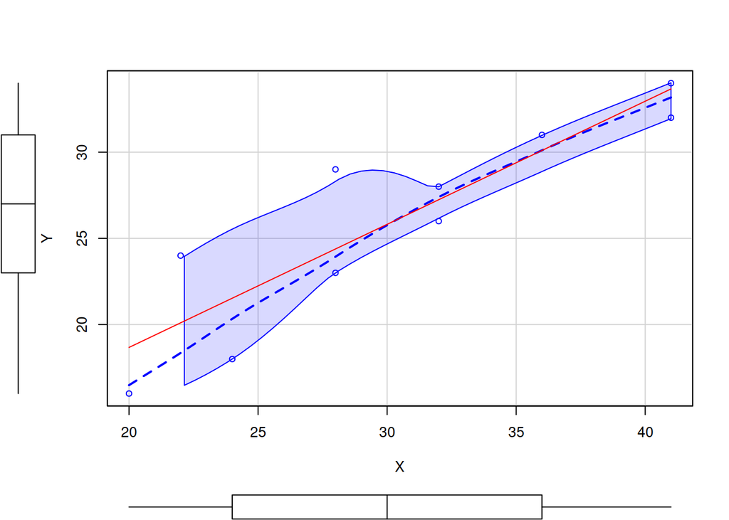

```r
library(car)
scatterplot(Y~X,data = df, regLine=list(method=lm,  lwd=1, col="red") )
```

*Un lissage permet de se donner une idée précise de la relation existante entre deux variables et d’estimer la linéarité de cette relation !* existance des valeurs peux ou pas expliqué par le medel

ou encore

```r
library(lmtest)
raintest(model)
```

```
##
##  Rainbow test
##
## data:  model
## Rain = 2.6149, df1 = 5, df2 = 3, p-value = 0.2293
```

p-value sup a 5% linearité accepté

5-2)indépendance des residus

```r
library(performance)
library(lmtest)
check_autocorrelation(model)
```

```
## OK: Residuals appear to be independent and not autocorrelated (p = 0.334).
```

```r
dwtest(model)
```

```
##
##  Durbin-Watson test
##
## data:  model
## DW = 1.6837, p-value = 0.1808
## alternative hypothesis: true autocorrelation is greater than 0
```

il faut une p-value supérieure à 0,05 pour avoir indépendance.

*conclusion*: residus indépendance !!!

*Attention :* ce test n’évalue que l’autocorrélation entre résidus et le résidus qui suit directement (n+1) et non ceux séparés d’un intervalle (résidus+2) qui pourraient être autocorrélés dans un phénomène cyclique.

*On peut aussi visualiser l’indépendance avec ce graphique suivant :

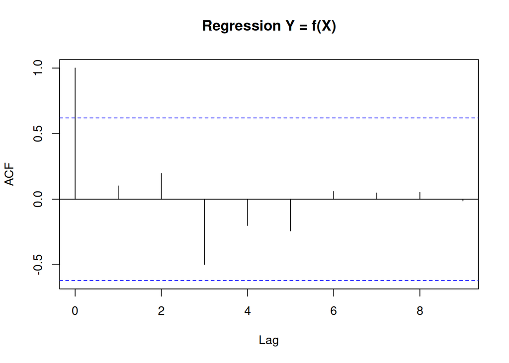

```r
library(stats)
acf(residuals(model), main="Regression Y = f(X)")
```

L’interprétation de ce graphique se fait de la manière suivante : -Le premier bâtonnet est très élevé, c’est l’auto-corrélation des résidus avec eux-même ! -Le deuxième bâtonnet indique l’auto-corrélation entre les résidus et les résidus n+1 : il y a auto-corrélation dès que le bâtonnet (lag) dépasse les pointillés. -Le troisième bâtonnet entre les résidus n et les résidus n+2… etc.

5-3)homoscedasticité

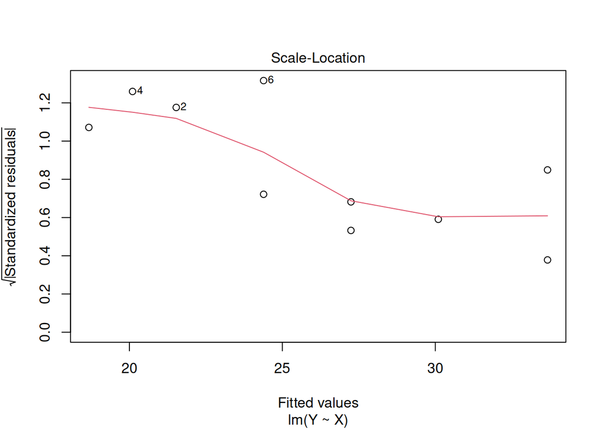

```r
library(car)
plot(model, which = 3)
```

On cherche ici une courbe rouge plane. L’homogénéité est à rejeter si celle-ci n’est pas horizontale.

*homoscedas rejeté

```r
library("lmtest") ;
bptest(model) # librairie lmtest
```

```
##
##  studentized Breusch-Pagan test
##
## data:  model
## BP = 3.6436, df = 1, p-value = 0.05628
```

```r
ncvTest(model) # librairie car
```

```
## Non-constant Variance Score Test
## Variance formula: ~ fitted.values
## Chisquare = 2.224827, Df = 1, p = 0.13581
```

L’homogénéité est rejeté si la p-value est inférieure à 0,05

```
    difficile de conclure !!!
```

```r
gqtest(model)
```

```
##
##  Goldfeld-Quandt test
##
## data:  model
## GQ = 0.39808, df1 = 3, df2 = 3, p-value = 0.7654
## alternative hypothesis: variance increases from segment 1 to 2
```

Vérification par le test de Goldfeld-Quandt (homogénéité : p-value > 0,05)

```r
library(performance)
check_heteroscedasticity(model)
```

```
## OK: Error variance appears to be homoscedastic (p = 0.136).
```

Homoscedasticité des residus verifié !!!

5-4)normalité

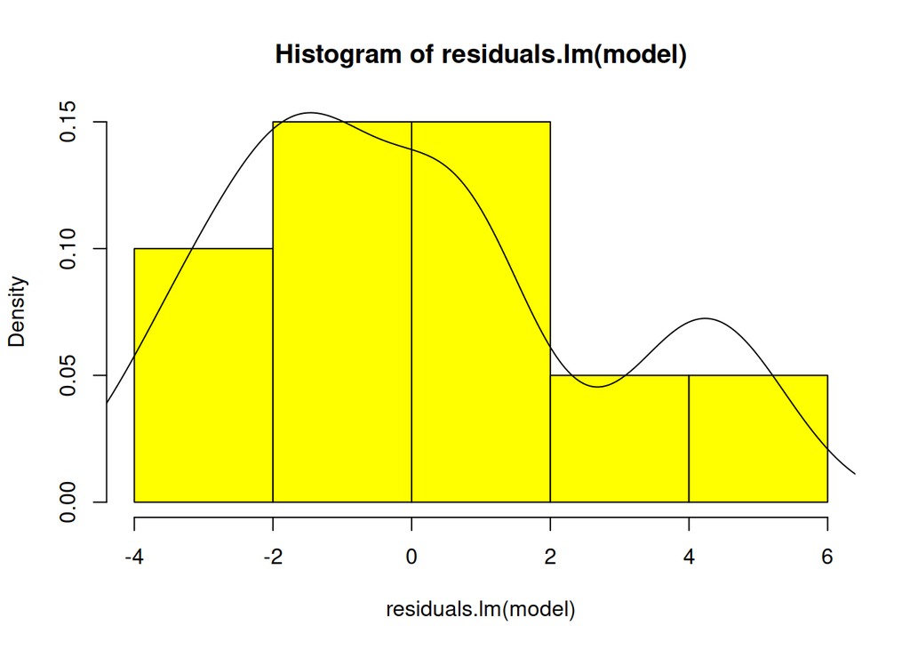

```r
hist(residuals.lm(model),col="yellow",freq=F)
densite <- density(residuals.lm(model)) # estimer la densité que représente ces différentes valeurs
lines(densite) # Superposer une ligne de densité à l'histogramme
```

autre methodes recommandé

```r
shapiro.test(residuals.lm(model))
```

```
##
##  Shapiro-Wilk normality test
##
## data:  residuals.lm(model)
## W = 0.9315, p-value = 0.4628
```

```r
check_normality(model)
```

```
## OK: residuals appear as normally distributed (p = 0.409).
```

Normalité des residus Validé…!!!

5-5) absence de valeurs aberrantes (toute les valeurs doivent êtres présentes)

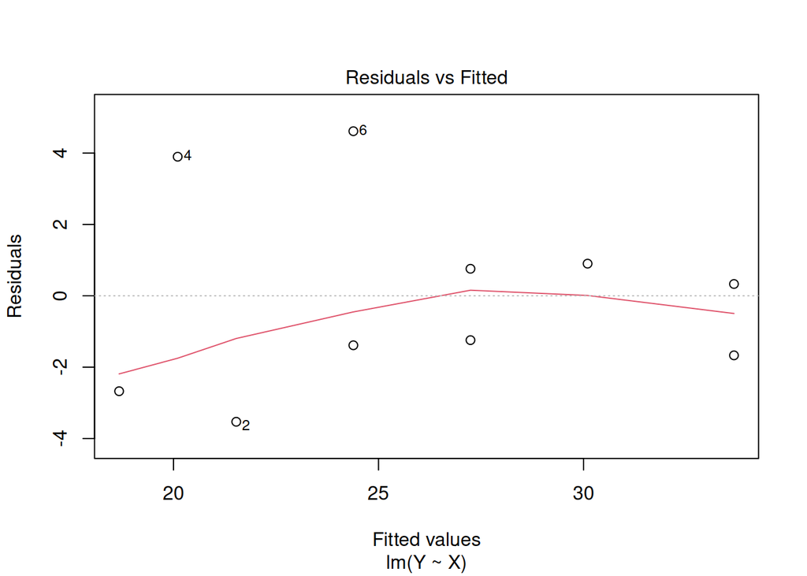

```r
plot(model, which = 1)
```

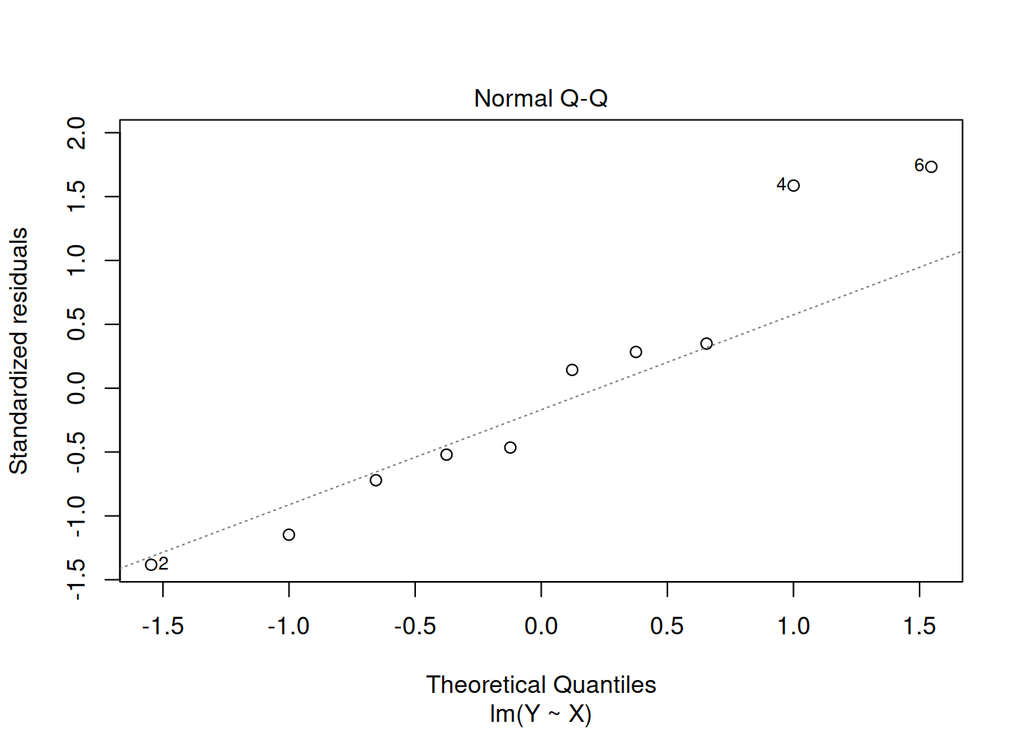

```r
plot(model, which = 2)
```

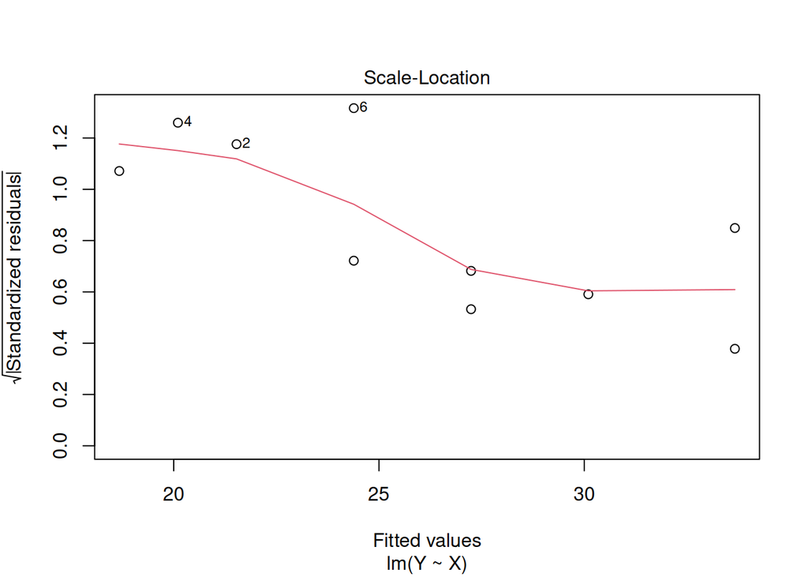

```r
plot(model, which = 3)
```

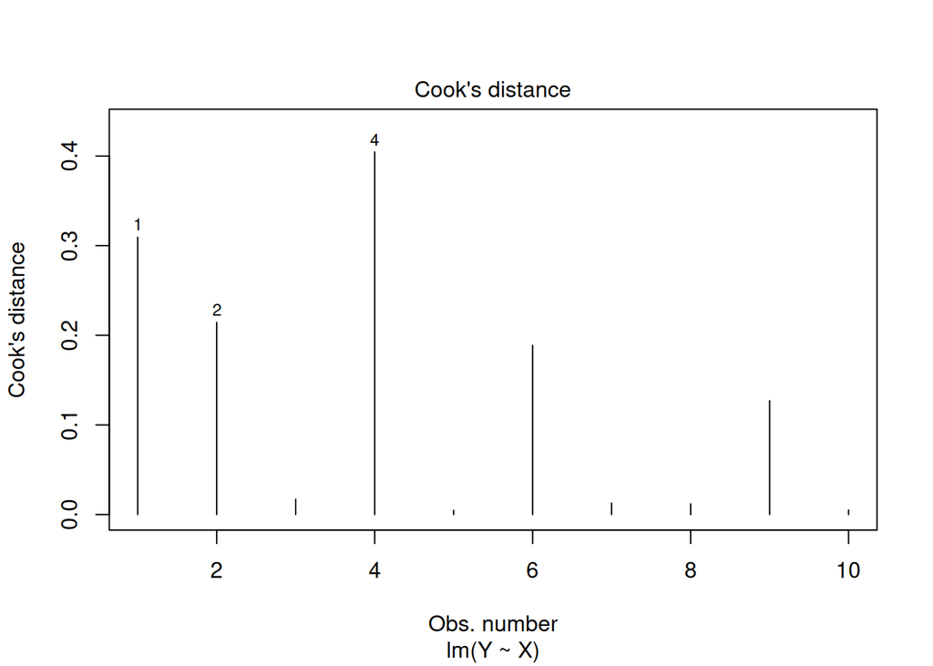

```r
plot(model, which = 4)
```

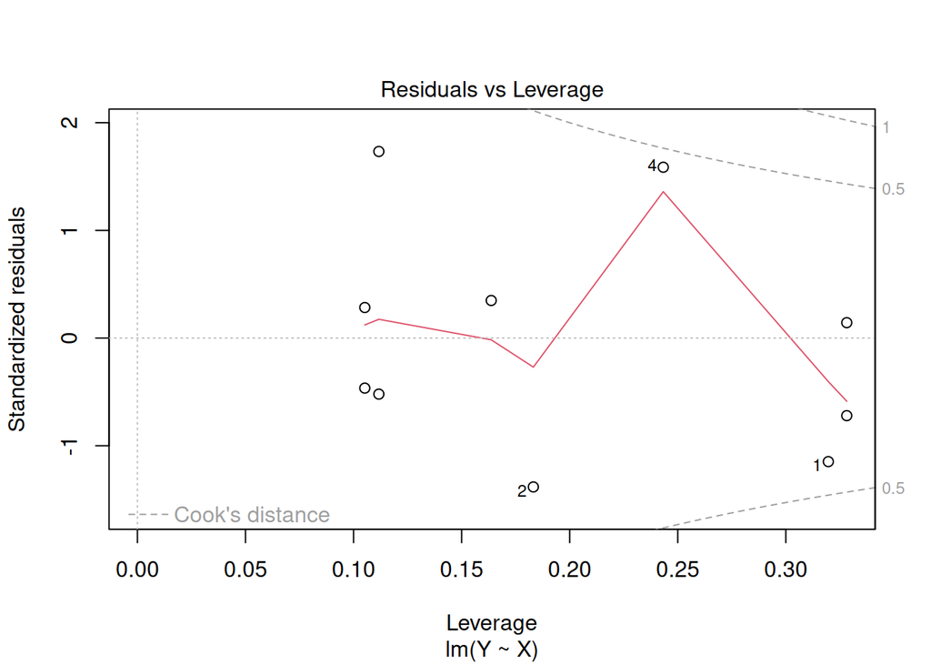

```r
plot(model, which = 5) # ce qui m'interesse !!!!
```

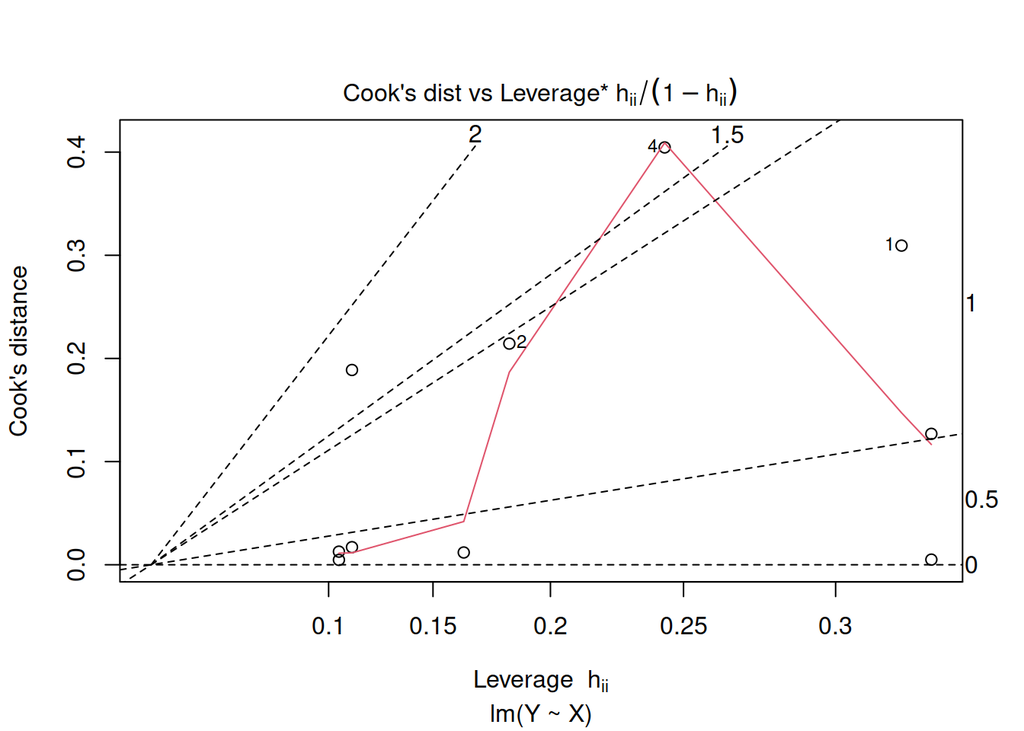

```r
plot(model, which = 6)
```

le lien de la documentation de tout les cas: https://data.library.virginia.edu/diagnostic-plots/

aucune valeur en dehors de la cook’s distance Donc pas de valeur extrême

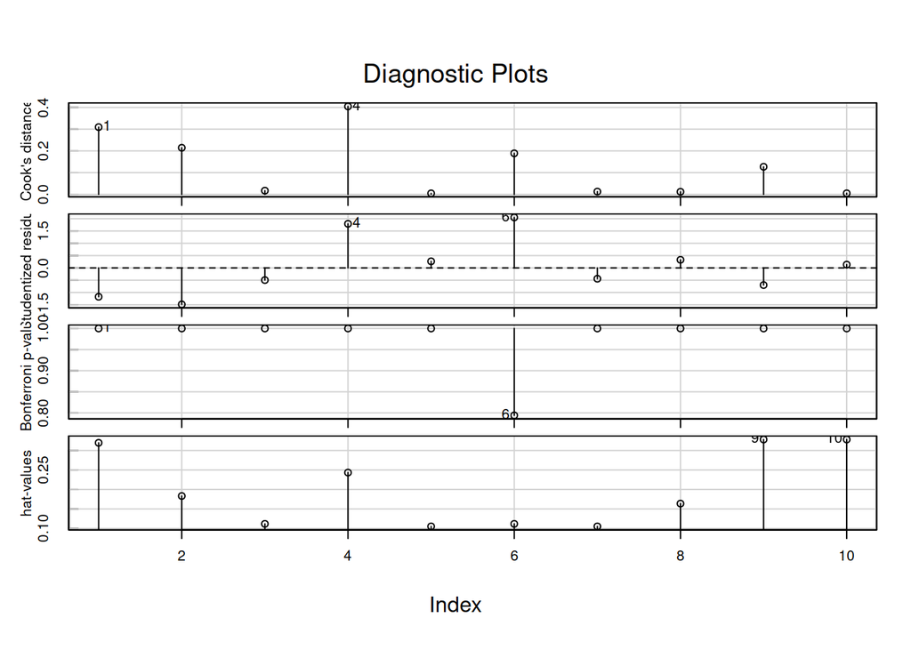

```r
influenceIndexPlot(model)
```

pas reelement de données extrême essayons kamem d’eliminer quelque valeur qui s’y raproche et comparons les deux modèles

```r
 model2 <- lm(Y~X, data=df[-c(2,4),])
    compareCoefs(model ,model2)
```

```
## Calls:
## 1: lm(formula = Y ~ X)
## 2: lm(formula = Y ~ X, data = df[-c(2, 4), ])
##
##             Model 1 Model 2
## (Intercept)    4.39    3.36
## SE             3.97    4.28
##
## X             0.714   0.745
## SE            0.127   0.130
##
```

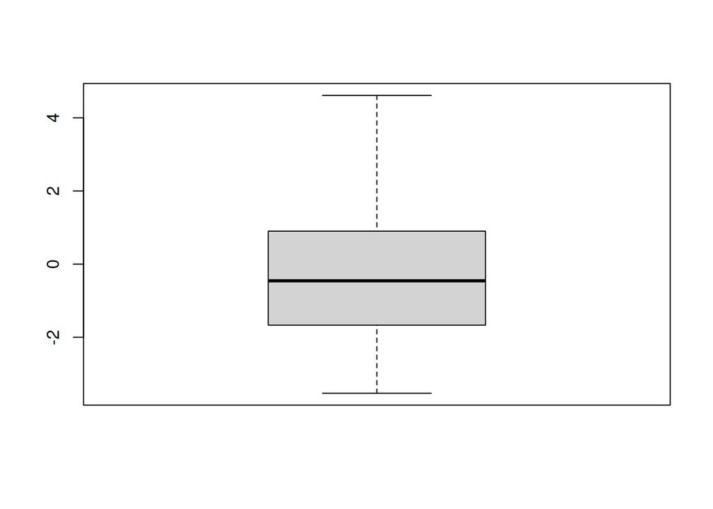

```r
boxplot(df2$resid)
```

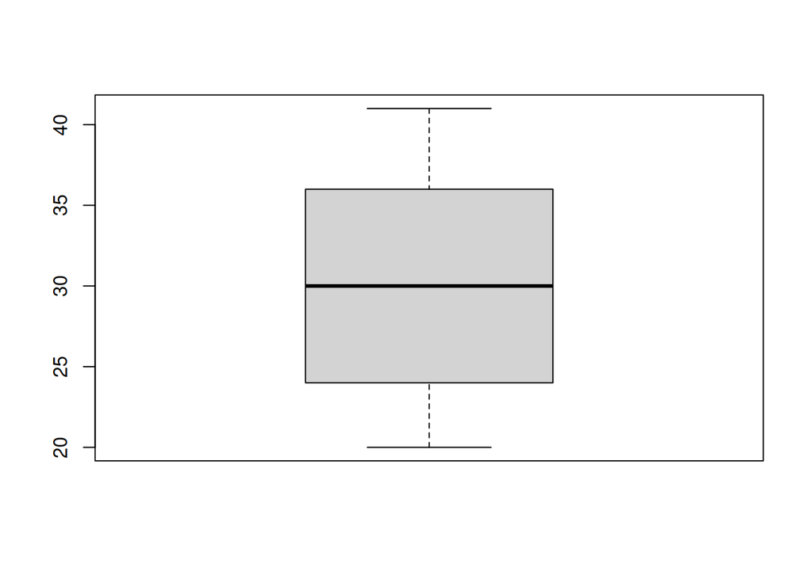

```r
boxplot(X)
```

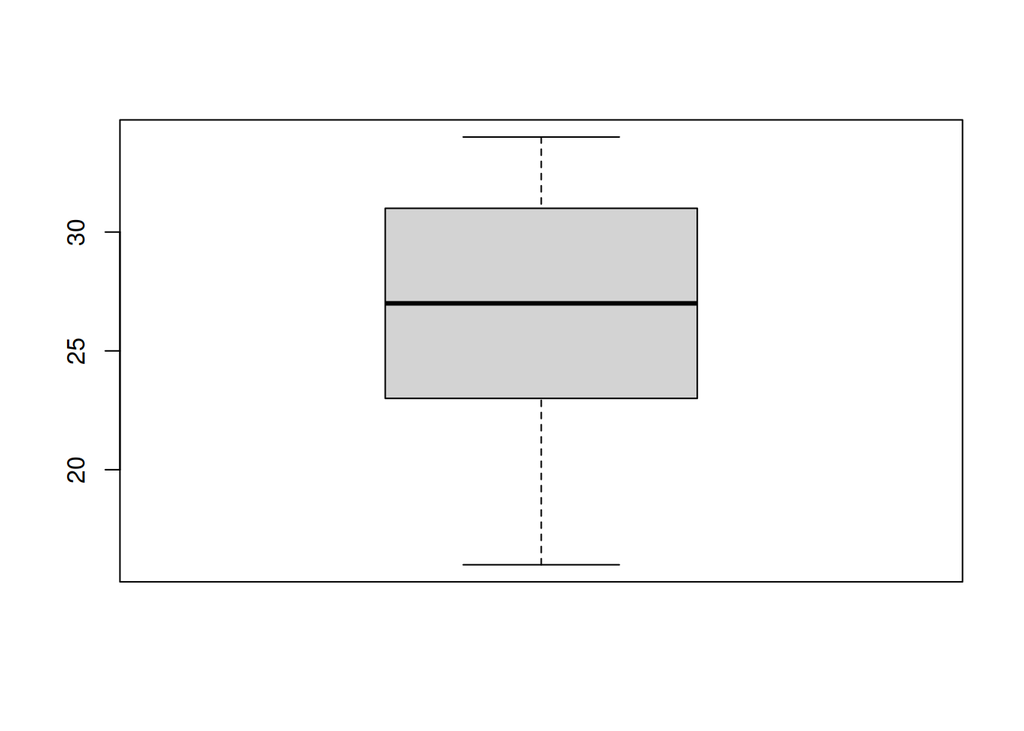

```r
boxplot(Y)
```

limites de turkey bien aux limites de notre cadrant Donc pas de valeur extrême quelque soit la variable

```r
library(KefiR)
valreg
```

[output not shown]

[output cut: 124 more lines]

[output not shown]

```
## 01- Analysis of the p-values of the model and its coefficients.
##  Good significance of the model. p-value: 0.0005048663
##  Warning!
##  Bad significance of the coefficients. max(p.value) : 0.3008742
## 02- Analysis of the adequacy of model (Equivalence between the global model and the model established on the best points.).
##  Rainbow test (raintest()) - Good adequacy. p.value :  0.5017592
## 03- Analysis of independence of the residuals.
##  Durbin-Watson test (dwtest()) - Good independence of the residuals. p.value :  0.7984325
## 04- Analysis of distribution of residuals.
##  Shapiro-Wilk test (shapiro.test()) - Normal distribution of residuals. p.value :  0.4628321
## 05- Analysis of variance of residuals.
##  Breush-Pagan test (bptest()) - Constant variance of the residuals. p.value :  0.05628425
## 06- Analysis of leverage effect.
##  Cook's distance (cooks.distance()) - No leverage effect. max(cooks.distance()) 0.4045383
## 07- Analysis of solidity of model by boostrap.
```

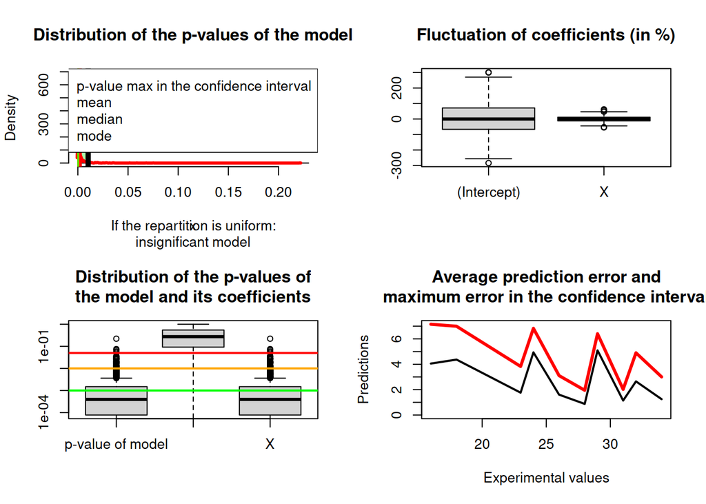

```
##  Warning!
##  Bootstrap (bootreg()) - Fragility of the model in boostrap. Please, use bootreg()
```

```
## [1] FALSE
```

```r
valreg(model, plot = TRUE )
```

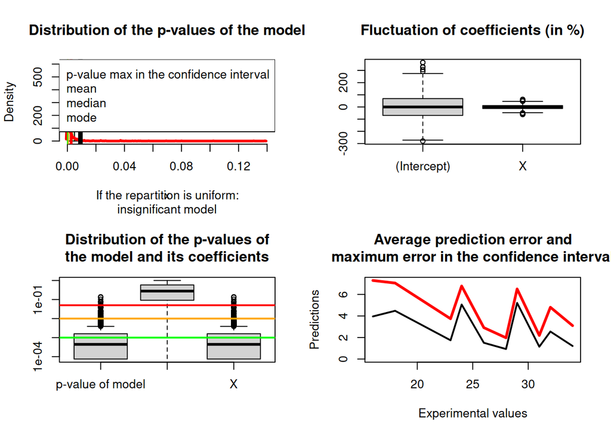

```
                              _____FIN____
```

```r
bootreg(model)
```